# Coursework Report

*N* removed NAs: 2

*N* removed typo: 1

*N* removed <18: 18

*N* total clean: 129

| Group | *N* | *M*<sub>age</sub> | *M*<sub>rating</sub> |
| --- | --- | --- | --- |
| Control | 61 | 20.98 | 6.64 |
| Experim | 68 | 20.68 | 5.77 |

**Main analysis results**

*t*(127) = 5.96, *p* < .001

[interactive chart not shown]

[figure not shown]

[interactive chart not shown]

# Coursework Report

Analysing Data, Spring 2020

# Methods

## Participants

Initially the study consisted of 150 participants. However 18 of these participants were removed for being under the age of 18 years of age. Furthermore, three further participants was also removed for giving an ambiguous age. Therefore, after controlling for age, the results of 129 female participants between the age of 18-29 years were used in the study.The participants had a mean age of 20.8 and a standard deviation of 2.07.

Figure 1. Descriptives of Age by Condition

| Condition | N | Mean of Age | SD of Age | Minimum Age | Maximum Age |
| --- | --- | --- | --- | --- | --- |
| control | 61 | 20.98 | 1.95 | 18 | 25 |
| experimental | 68 | 20.68 | 2.17 | 18 | 29 |

## Design

The present research examines the hypothesis that red enhances women’s attraction to men.

Participants viewed a black and white photo of a moderately attractive man on a red (experimental condition) or white (control condition) background. Perceived attractiveness was measured using three questions: “How attractive do you think this person is?” “How pleasant is this person to look at?” and “If I were to meet the person in this picture face to face, I would think he is attractive.” The items were rated on 9-point scales ranging from 1 (extremely unattractive) to 9 (extremely attractive). The answers to these questions were than averaged to create a mean composite score for each individual participant.

I predict that viewing a red coloured frame around a moderately attractive man will increase mean ratings of attractiveness in comparison to a white frame. I will conduct a t-test statistical analysis to test this hypothesis.

# Results

An independent-samples t test examining the influence of color condition on perceived attractiveness revealed that a photographed male with a white frame (control condition) received higher mean attractiveness scores (*M* = 6.64) compared to the red frame experimental condition (*M* = 5.77). This difference in means was significant (*M*<sub>diff</sub> = 0.88, 95% CI [0.58, 1.17], *t* (127) = 5.96, *p* = 0). This does not support my hypothesis that red enhances women’s attraction to men.

Figure 2. Composite Score by ID, Condition and Age

| ID Code | Condition | Age | Question 1 | Question 2 | Question 3 | Mean Composite Score |
| --- | --- | --- | --- | --- | --- | --- |
| MBNE | experimental | 19 | 5 | 5 | 6 | 5.33 |
| LUKI | experimental | 20 | 9 | 5 | 5 | 6.33 |
| PIYN | experimental | 19 | 7 | 5 | 4 | 5.33 |
| VXSD | experimental | 19 | 6 | 7 | 7 | 6.67 |
| NQWU | experimental | 19 | 8 | 6 | 6 | 6.67 |
| OLEL | experimental | 18 | 6 | 7 | 5 | 6.00 |
| ZLLC | experimental | 22 | 6 | 5 | 6 | 5.67 |
| ARHQ | experimental | 20 | 7 | 6 | 5 | 6.00 |
| GKCJ | experimental | 18 | 4 | 6 | 6 | 5.33 |
| HGBN | experimental | 25 | 7 | 5 | 4 | 5.33 |
| IVIA | experimental | 20 | 6 | 4 | 5 | 5.00 |
| XQLR | experimental | 20 | 7 | 7 | 6 | 6.67 |
| HNSG | experimental | 20 | 6 | 6 | 7 | 6.33 |
| LTSZ | experimental | 29 | 6 | 6 | 7 | 6.33 |
| UPND | experimental | 18 | 7 | 8 | 5 | 6.67 |
| CIJW | experimental | 21 | 8 | 6 | 5 | 6.33 |
| BGLU | experimental | 21 | 5 | 4 | 4 | 4.33 |
| IPOX | experimental | 18 | 9 | 4 | 7 | 6.67 |
| SBYP | experimental | 26 | 5 | 8 | 5 | 6.00 |
| VDES | experimental | 21 | 6 | 6 | 7 | 6.33 |
| TDDU | experimental | 20 | 5 | 5 | 4 | 4.67 |
| UTNF | experimental | 23 | 6 | 6 | 5 | 5.67 |
| KMCO | experimental | 18 | 7 | 5 | 4 | 5.33 |
| LEGO | experimental | 21 | 6 | 7 | 5 | 6.00 |
| MQAQ | experimental | 22 | 5 | 6 | 5 | 5.33 |
| EWTI | experimental | 20 | 7 | 5 | 8 | 6.67 |
| ZNAG | experimental | 19 | 6 | 7 | 6 | 6.33 |
| HECC | experimental | 22 | 4 | 5 | 4 | 4.33 |
| DJLT | experimental | 21 | 5 | 7 | 5 | 5.67 |
| TJJC | experimental | 23 | 7 | 7 | 3 | 5.67 |

[output cut: 99 more lines]

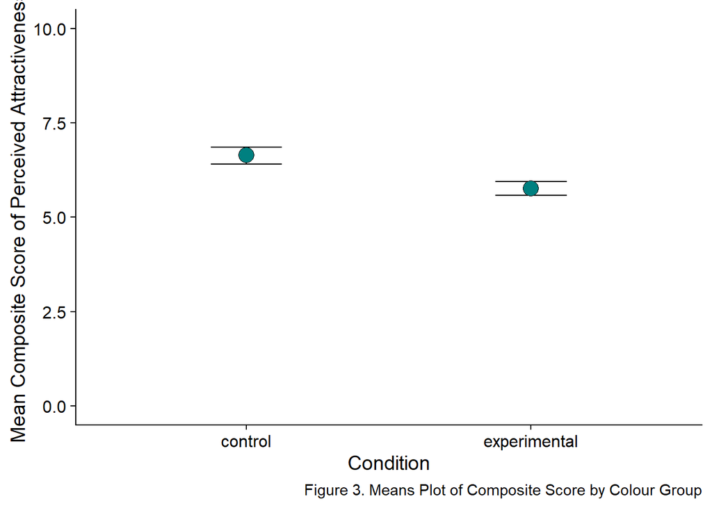

# Discussion

Elliot et al (2010) showed that presenting men in conjunction with the colour red enhances their attractiveness in the eyes of female observers. The purpose of this study was to investigate the robustness of this red effect by replicating the paradigm used by Elliot et al.

However, the results of the present research contrast with the results found by Elliot et al. This study showed that men presented in conjunction with the colour red were rated as less attractive than men presented in conjunction with the colour white. This pattern of results suggests that the red effect is not as robust as reported in the multiple successful replications conducted by Elliot et al.

As well as the way in which red is presented in conjunction to the photographed man, other factors may also influence attractiveness ratings, which in turn may weaken or distort the red effect. For example, Hesslinger, Goldbach and Carbon (2015) found that the style of apparel worn has a greater effect on perceived attractiveness than the colour red. Furthermore, it may be the case that there are other, undiscovered factors that affect perceived attractiveness ratings that have not been accounted for in this study, weakening the validity of the present research.

Future research should aim at either ruling out the presence of other factors or discovering them, when conducting similar experiments.

Overall, the results of this study suggest that the effect red has on perceived attractiveness is not as robust as once thought. However, factors other than colour, including style of apparel and the method in which the colour red is presented may be one possible explanation for these contrasting results.

# References

Elliot, A. J., Niesta Kayser, D., Greitemeyer, T., Lichtenfeld, S., Gramzow, R. H., Maier, M. A., & Liu, H. (2010). Red, rank, and romance in women viewing men. Journal of Experimental Psychology: General, 139(3), 399–417. https://doi.org/10.1037/a0019689

Hesslinger, V. M., Goldbach, L., & Carbon, C.-C. (2015). Men in red: A reexamination of the red-attractiveness effect. Psychonomic Bulletin & Review, 22(4), 1142–1148. https://doi.org/10.3758/s13423-015-0866-8

Re, D. E., Whitehead, R. D., Xiao, D., & Perrett, D. I. (2011). Oxygenated-blood colour change thresholds for perceived facial redness, health, and attractiveness. PLoS ONE, 6(3), e17859. https://doi.org/10.1371/journal.pone.0017859

Stephen, I. D., & McKeegan, A. M. (2010). Lip colour affects perceived sex typicality and attractiveness of human faces. Perception, 39(8), 1104–1110. https://doi.org/10.1068/p6730

Wagge, J. R., Baciu, C., Banas, K., Nadler, J. T., Schwarz, S., Weisberg, Y. J., IJzerman, H., Legate, N., & Grahe, J. E. (2018). A demonstration of the collaborative replication and education project: Replication attempts of the red-romance effect [Preprint]. PsyArXiv. https://doi.org/10.31234/osf.io/chax8